# Convergence conditionnelle et modèles de régression en assurance

Karim Barigou

# 1 Motivation

Soit $S_i$ le montant total des sinistres associé au contrat $i$. Pour un portefeuille de $n$ contrats, définissons le montant agrégé

$$T_n=\sum_{j=1}^n S_j.$$

Le portefeuille observé fournit une information globale, $T_n$, sur la sinistralité totale. Une question naturelle est alors la suivante : dans quelle mesure la connaissance du total $T_n$ modifie-t-elle la meilleure prédiction du sinistre individuel $S_i$ ?

Le transparent initial propose l’idée suivante :

$$\mathbb E[S_i\mid T_n]\longrightarrow \mu_i,
\qquad
\mu_i=\mathbb E[S_i],$$

lorsque la taille du portefeuille augmente.

L’intuition est que, si le contrat $i$ représente une part négligeable d’un portefeuille de plus en plus grand, le total agrégé devient de moins en moins informatif sur ce contrat particulier. La meilleure prédiction de $S_i$ fondée uniquement sur $T_n$ revient alors vers sa moyenne individuelle $\mu_i$.

# 2 Une formulation mathématique plus précise

## 2.1 Le contrat considéré doit rester fixé

Dans tout le document, $i$ désigne un contrat fixé, tandis que $n$ augmente. Il faut donc lire

$$S_i \quad \text{fixé},
\qquad
T_n=S_i+\sum_{j\ne i}S_j,
\qquad
n\to\infty.$$

L’information contenue dans $T_n$ sur $S_i$ se dilue lorsque la variabilité produite par les autres contrats devient dominante.

## 2.2 Le mode de convergence doit être indiqué

Une formulation utile est la convergence dans $L^2$ :

$$\boxed{
\mathbb E[S_i\mid T_n]-\mu_i
\xrightarrow{L^2}0.
}$$

Elle signifie que

$$\mathbb E\left[
\left(
\mathbb E[S_i\mid T_n]-\mu_i
\right)^2
\right]
\longrightarrow 0.$$

Comme

$$\mathbb E\left[\mathbb E[S_i\mid T_n]\right]
=\mathbb E[S_i]=\mu_i,$$

cette quantité est aussi égale à

$$\operatorname{Var}\left(\mathbb E[S_i\mid T_n]\right).$$

Ainsi, la convergence dans $L^2$ équivaut ici à

$$\operatorname{Var}\left(\mathbb E[S_i\mid T_n]\right)
\longrightarrow 0.$$

Elle implique également la convergence en probabilité :

$$\mathbb E[S_i\mid T_n]
\xrightarrow{\mathbb P}\mu_i.$$

## 2.3 L’indépendance seule ne suffit pas

L’hypothèse selon laquelle $S_1,S_2,\ldots$ sont indépendantes, mais pas nécessairement identiquement distribuées, ne suffit pas à elle seule. Il faut aussi éviter qu’un petit nombre de contrats domine indéfiniment le portefeuille.

Des conditions suffisantes typiques demandent que :

- $S_i$ soit intégrable, et souvent de carré intégrable ;
- le contrat $i$ soit fixé lorsque $n$ augmente ;
- la variance du reste du portefeuille augmente ;
- aucun contrat ne domine la variance totale ;
- une condition de type Lindeberg ou une régularité analogue permette une approximation asymptotique du total.

Une condition de négligeabilité souvent rencontrée est

$$\frac{\max_{1\leq j\leq n}\operatorname{Var}(S_j)}
{\sum_{j=1}^n\operatorname{Var}(S_j)}
\longrightarrow 0.$$

Elle exprime qu’aucun contrat ne représente une part non négligeable de la variance totale.

> **Message important.** Contrairement à la loi des grands nombres classique, la convergence d’une espérance conditionnelle n’est pas une conséquence immédiate de l’indépendance. Elle doit être justifiée par une structure probabiliste ou par des conditions supplémentaires.

# 3 Intuition : dilution de l’information individuelle

Écrivons

$$T_n=S_i+R_{i,n},
\qquad
R_{i,n}=\sum_{\substack{j=1\\j\ne i}}^nS_j.$$

Par indépendance, $S_i$ et $R_{i,n}$ sont indépendants. Le total $T_n$ contient bien $S_i$, mais il contient également le bruit produit par tous les autres contrats.

Si

$$\operatorname{Var}(R_{i,n})\longrightarrow\infty$$

alors que $\operatorname{Var}(S_i)$ reste fixe, la contribution relative du contrat $i$ devient négligeable :

$$\frac{\operatorname{Var}(S_i)}
{\operatorname{Var}(T_n)}
=
\frac{\operatorname{Var}(S_i)}
{\operatorname{Var}(S_i)+\operatorname{Var}(R_{i,n})}
\longrightarrow0.$$

Le total renseigne alors surtout sur le reste du portefeuille, et de moins en moins sur $S_i$.

# 4 Exemple exact 1 : risques normaux hétérogènes

Supposons que les risques soient indépendants et que

$$S_j\sim N(\mu_j,\sigma_j^2),
\qquad j=1,\ldots,n.$$

Le couple $(S_i,T_n)$ est gaussien. La formule de régression normale donne exactement

$$\mathbb E[S_i\mid T_n]
=
\mu_i+
\frac{\operatorname{Cov}(S_i,T_n)}
{\operatorname{Var}(T_n)}
\left(T_n-\mathbb E[T_n]\right).$$

Grâce à l’indépendance,

$$\operatorname{Cov}(S_i,T_n)=\sigma_i^2,
\qquad
\operatorname{Var}(T_n)=V_n:=\sum_{j=1}^n\sigma_j^2.$$

Par conséquent,

$$\boxed{
\mathbb E[S_i\mid T_n]
=
\mu_i+
\frac{\sigma_i^2}{V_n}
\left(T_n-\sum_{j=1}^n\mu_j\right).
}$$

Cette espérance conditionnelle est aléatoire, car elle dépend de $T_n$. Son écart quadratique moyen à $\mu_i$ est

$$\begin{aligned}
\mathbb E\left[
\left(
\mathbb E[S_i\mid T_n]-\mu_i
\right)^2
\right]
&=
\left(\frac{\sigma_i^2}{V_n}\right)^2
\operatorname{Var}(T_n)\\
&=
\frac{\sigma_i^4}{V_n}.
\end{aligned}$$

Ainsi, si $V_n\to\infty$,

$$\mathbb E[S_i\mid T_n]-\mu_i
\xrightarrow{L^2}0.$$

Dans le cas identiquement distribué, avec $\sigma_j^2=\sigma^2$,

$$V_n=n\sigma^2$$

et donc

$$\mathbb E\left[
\left(
\mathbb E[S_i\mid T_n]-\mu_i
\right)^2
\right]
=
\frac{\sigma^2}{n}.$$

Le taux quadratique est donc d’ordre $1/n$, et l’écart-type de l’espérance conditionnelle est d’ordre $1/\sqrt n$.

# 5 Illustration numérique 1 : modèle normal hétérogène

Nous considérons un contrat fixé $i=1$ avec

$$\mu_1=120,
\qquad
\sigma_1=60.$$

Les autres contrats ont des moyennes et variances différentes. Nous utilisons ici une suite déterministe de paramètres afin d’illustrer un portefeuille indépendant, mais non identiquement distribué.

```r
n_max <- 5000
indice <- 1:n_max

mu_j <- 100 + 20 * sin(indice / 25)
sigma_j <- 35 + 15 * (1 + cos(indice / 17)) / 2

mu_j[1] <- 120
sigma_j[1] <- 60

n_valeurs <- c(2, 5, 10, 25, 50, 100, 250, 500, 1000, 2500, 5000)
variance_totale <- cumsum(sigma_j^2)

mse_theorique_normal <- sigma_j[1]^4 / variance_totale[n_valeurs]
sd_conditionnelle_normal <- sqrt(mse_theorique_normal)
poids_total_normal <- sigma_j[1]^2 / variance_totale[n_valeurs]

resultats_normaux <- data.frame(
  n = n_valeurs,
  poids_du_total = poids_total_normal,
  ecart_type_conditionnel = sd_conditionnelle_normal,
  EQM_theorique = mse_theorique_normal
)

resultats_normaux$poids_du_total <-
  signif(resultats_normaux$poids_du_total, 4)
resultats_normaux$ecart_type_conditionnel <-
  signif(resultats_normaux$ecart_type_conditionnel, 4)
resultats_normaux$EQM_theorique <-
  signif(resultats_normaux$EQM_theorique, 4)

knitr::kable(
  resultats_normaux,
  col.names = c(
    "$n$",
    "$\\sigma_1^2/V_n$",
    "Écart-type de $\\mathbb E[S_1\\mid T_n]$",
    "EQM théorique autour de $\\mu_1$"
  ),
  caption = "Dilution de l'information agrégée dans le modèle normal"
)
```

Dilution de l’information agrégée dans le modèle normal

| $n$ | $\sigma_1^2/V_n$ | Écart-type de $\mathbb E[S_1\mid T_n]$ | EQM théorique autour de $\mu_1$ |
| --- | --- | --- | --- |
| 2 | 0.5907000 | 46.110 | 2126.000 |
| 5 | 0.2661000 | 30.950 | 957.800 |
| 10 | 0.1405000 | 22.490 | 505.900 |
| 25 | 0.0626400 | 15.020 | 225.500 |
| 50 | 0.0382000 | 11.730 | 137.500 |
| 100 | 0.0199900 | 8.483 | 71.960 |
| 250 | 0.0076910 | 5.262 | 27.690 |
| 500 | 0.0039640 | 3.778 | 14.270 |
| 1000 | 0.0019530 | 2.652 | 7.032 |
| 2500 | 0.0007839 | 1.680 | 2.822 |
| 5000 | 0.0003929 | 1.189 | 1.414 |

Le coefficient $\sigma_1^2/V_n$ mesure la sensibilité de la prédiction de $S_1$ à une variation du total $T_n$. Il tend vers zéro lorsque la variance totale du portefeuille augmente.

## 5.1 Vérification par simulation

Pour chaque taille $n$, simulons directement le total normal

$$T_n\sim N\left(\sum_{j=1}^n\mu_j,V_n\right)$$

puis calculons $\mathbb E[S_1\mid T_n]$ à partir de la formule exacte.

```r
B <- 20000
n_sim <- c(2, 10, 50, 250, 1000, 5000)

simulation_normale <- lapply(n_sim, function(n) {
  moyenne_totale <- sum(mu_j[1:n])
  variance_n <- sum(sigma_j[1:n]^2)
  total <- rnorm(B, moyenne_totale, sqrt(variance_n))
  prediction <- mu_j[1] +
    sigma_j[1]^2 / variance_n * (total - moyenne_totale)

  data.frame(
    n = n,
    prediction = prediction,
    ecart = prediction - mu_j[1]
  )
})

simulation_normale <- do.call(rbind, simulation_normale)

resume_normal <- do.call(
  rbind,
  lapply(n_sim, function(n) {
    ecarts_n <- simulation_normale$ecart[simulation_normale$n == n]

    data.frame(
      n = n,
      moyenne = mean(ecarts_n),
      ecart_type = sd(ecarts_n),
      EQM = mean(ecarts_n^2),
      quantile_025 = unname(quantile(ecarts_n, 0.025)),
      quantile_975 = unname(quantile(ecarts_n, 0.975))
    )
  })
)

rownames(resume_normal) <- NULL

knitr::kable(
  resume_normal,
  digits = 4,
  col.names = c(
    "$n$", "Biais simulé", "Écart-type simulé", "EQM simulée",
    "Quantile 2,5 %", "Quantile 97,5 %"
  ),
  caption = "Simulation de la convergence conditionnelle dans le modèle normal"
)
```

Simulation de la convergence conditionnelle dans le modèle normal

| $n$ | Biais simulé | Écart-type simulé | EQM simulée | Quantile 2,5 % | Quantile 97,5 % |
| --- | --- | --- | --- | --- | --- |
| 2 | 0.4874 | 46.2817 | 2142.1227 | -89.1637 | 91.4551 |
| 10 | 0.0236 | 22.4467 | 503.8282 | -43.7278 | 43.0850 |
| 50 | -0.1593 | 11.8047 | 139.3698 | -23.6693 | 22.9306 |
| 250 | 0.0379 | 5.2717 | 27.7910 | -10.3099 | 10.4564 |
| 1000 | 0.0000 | 2.6692 | 7.1242 | -5.2749 | 5.2419 |
| 5000 | 0.0100 | 1.1939 | 1.4255 | -2.3480 | 2.3658 |

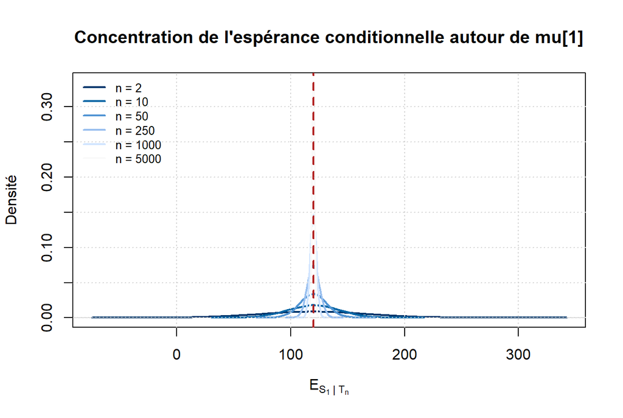

```r
couleurs <- hcl.colors(length(n_sim), "Blues 3")

densites <- lapply(n_sim, function(n) {
  density(
    simulation_normale$prediction[simulation_normale$n == n]
  )
})

limite_x <- range(unlist(lapply(densites, function(d) d$x)))
limite_y <- c(0, max(unlist(lapply(densites, function(d) d$y))))

plot(
  densites[[1]],
  xlim = limite_x,
  ylim = limite_y,
  lwd = 2,
  col = couleurs[1],
  xlab = expression(E[S[1] * " | " * T[n]]),
  ylab = "Densité",
  main = "Concentration de l'espérance conditionnelle autour de mu[1]"
)

for (k in 2:length(densites)) {
  lines(densites[[k]], lwd = 2, col = couleurs[k])
}

abline(v = mu_j[1], lwd = 2, lty = 2, col = "firebrick")
legend(
  "topleft",
  legend = paste("n =", n_sim),
  col = couleurs,
  lwd = 2,
  bty = "n",
  cex = 0.8
)
grid()
```

Lorsque $n$ augmente, la distribution de $\mathbb E[S_1\mid T_n]$ se concentre autour de $\mu_1=120$.

# 6 Exemple exact 2 : risques de Poisson hétérogènes

Supposons maintenant que

$$S_j\sim\operatorname{Poisson}(\lambda_j)$$

indépendamment, avec des paramètres éventuellement différents. Posons

$$\Lambda_n=\sum_{j=1}^n\lambda_j.$$

Alors

$$T_n=\sum_{j=1}^nS_j
\sim\operatorname{Poisson}(\Lambda_n).$$

Conditionnellement à $T_n=t$, le vecteur $(S_1,\ldots,S_n)$ suit une loi multinomiale :

$$(S_1,\ldots,S_n)\mid T_n=t
\sim
\operatorname{Multinomial}\left(
t;
\frac{\lambda_1}{\Lambda_n},\ldots,
\frac{\lambda_n}{\Lambda_n}
\right).$$

Par conséquent,

$$\boxed{
\mathbb E[S_i\mid T_n]
=
\frac{\lambda_i}{\Lambda_n}T_n.
}$$

Comme $\mu_i=\mathbb E[S_i]=\lambda_i$,

$$\mathbb E[S_i\mid T_n]-\lambda_i
=
\frac{\lambda_i}{\Lambda_n}(T_n-\Lambda_n).$$

L’erreur quadratique moyenne vaut exactement

$$\begin{aligned}
\mathbb E\left[
\left(
\mathbb E[S_i\mid T_n]-\lambda_i
\right)^2
\right]
&=
\frac{\lambda_i^2}{\Lambda_n^2}
\operatorname{Var}(T_n)\\
&=
\frac{\lambda_i^2}{\Lambda_n}.
\end{aligned}$$

Dès que $\Lambda_n\to\infty$,

$$\mathbb E[S_i\mid T_n]-\lambda_i
\xrightarrow{L^2}0.$$

Cet exemple est particulièrement utile, car il montre une convergence exacte pour des risques discrets, positifs et non identiquement distribués.

# 7 Illustration numérique 2 : modèle de Poisson hétérogène

Considérons un contrat fixé avec $\lambda_1=2$, tandis que les autres paramètres varient selon les caractéristiques des assurés.

```r
lambda_j <- exp(
  log(1.5) +
    0.35 * sin(indice / 20) +
    0.15 * cos(indice / 7)
)
lambda_j[1] <- 2

lambda_totale <- cumsum(lambda_j)
mse_theorique_poisson <- lambda_j[1]^2 / lambda_totale[n_valeurs]
sd_conditionnelle_poisson <- sqrt(mse_theorique_poisson)
poids_total_poisson <- lambda_j[1] / lambda_totale[n_valeurs]

resultats_poisson <- data.frame(
  n = n_valeurs,
  poids_du_total = poids_total_poisson,
  ecart_type_conditionnel = sd_conditionnelle_poisson,
  EQM_theorique = mse_theorique_poisson
)

resultats_poisson$poids_du_total <-
  signif(resultats_poisson$poids_du_total, 4)
resultats_poisson$ecart_type_conditionnel <-
  signif(resultats_poisson$ecart_type_conditionnel, 4)
resultats_poisson$EQM_theorique <-
  signif(resultats_poisson$EQM_theorique, 4)

knitr::kable(
  resultats_poisson,
  col.names = c(
    "$n$", "$\\lambda_1/\\Lambda_n$",
    "Écart-type de $\\mathbb E[S_1\\mid T_n]$",
    "EQM théorique autour de $\\lambda_1$"
  ),
  caption = "Convergence conditionnelle dans le modèle de Poisson"
)
```

Convergence conditionnelle dans le modèle de Poisson

| $n$ | $\lambda_1/\Lambda_n$ | Écart-type de $\mathbb E[S_1\mid T_n]$ | EQM théorique autour de $\lambda_1$ |
| --- | --- | --- | --- |
| 2 | 0.5272000 | 1.02700 | 1.054000 |
| 5 | 0.2159000 | 0.65720 | 0.431900 |
| 10 | 0.1087000 | 0.46630 | 0.217500 |
| 25 | 0.0445300 | 0.29840 | 0.089060 |
| 50 | 0.0202000 | 0.20100 | 0.040400 |
| 100 | 0.0121900 | 0.15610 | 0.024370 |
| 250 | 0.0051650 | 0.10160 | 0.010330 |
| 500 | 0.0025700 | 0.07169 | 0.005139 |
| 1000 | 0.0012870 | 0.05073 | 0.002574 |
| 2500 | 0.0005143 | 0.03207 | 0.001029 |
| 5000 | 0.0002570 | 0.02267 | 0.000514 |

## 7.1 Simulation des probabilités d’écart

La convergence en probabilité peut être illustrée en estimant

$$\mathbb P\left(
\left|\mathbb E[S_1\mid T_n]-\lambda_1\right|>\delta
\right)$$

pour plusieurs valeurs de $n$ et un seuil $\delta>0$.

```r
B_poisson <- 50000
n_sim_poisson <- c(2, 10, 50, 250, 1000, 5000)
delta <- 0.25

resume_poisson <- do.call(
  rbind,
  lapply(n_sim_poisson, function(n) {
    lambda_n <- sum(lambda_j[1:n])
    total <- rpois(B_poisson, lambda_n)
    prediction <- lambda_j[1] / lambda_n * total
    ecart <- prediction - lambda_j[1]

    data.frame(
      n = n,
      moyenne_prediction = mean(prediction),
      ecart_type_prediction = sd(prediction),
      EQM_simulee = mean(ecart^2),
      EQM_theorique = lambda_j[1]^2 / lambda_n,
      probabilite_ecart = mean(abs(ecart) > delta)
    )
  })
)

knitr::kable(
  resume_poisson,
  digits = 5,
  col.names = c(
    "$n$", "Moyenne de la prédiction", "Écart-type",
    "EQM simulée", "EQM théorique",
    paste0("$\\mathbb P(|\\cdot|>", delta, ")$")
  ),
  caption = "Simulation de la convergence dans le modèle de Poisson"
)
```

Simulation de la convergence dans le modèle de Poisson

| $n$ | Moyenne de la prédiction | Écart-type | EQM simulée | EQM théorique | $\mathbb P(&#124;\cdot&#124;>0.25)$ |
| --- | --- | --- | --- | --- | --- |
| 2 | 1.99298 | 1.02518 | 1.05102 | 1.05436 | 0.80824 |
| 10 | 1.99697 | 0.46330 | 0.21465 | 0.21746 | 0.64030 |
| 50 | 2.00092 | 0.20054 | 0.04021 | 0.04040 | 0.20808 |
| 250 | 2.00060 | 0.10166 | 0.01034 | 0.01033 | 0.01386 |
| 1000 | 1.99939 | 0.05081 | 0.00258 | 0.00257 | 0.00000 |
| 5000 | 1.99982 | 0.02253 | 0.00051 | 0.00051 | 0.00000 |

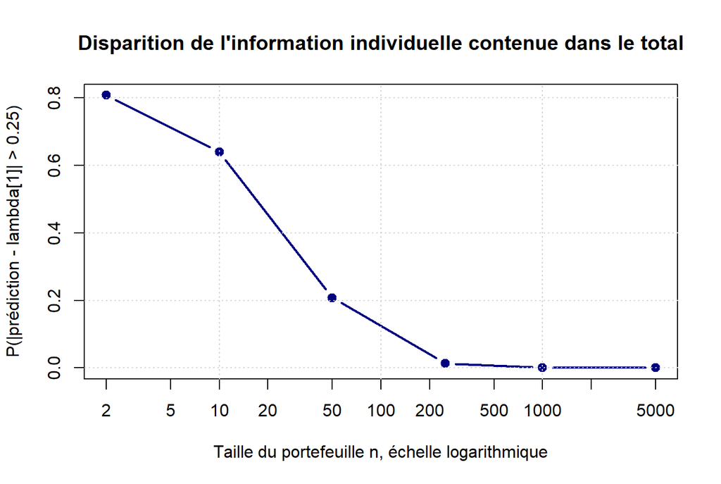

```r
plot(
  resume_poisson$n,
  resume_poisson$probabilite_ecart,
  type = "b",
  pch = 19,
  lwd = 2,
  log = "x",
  col = "navy",
  xlab = "Taille du portefeuille n, échelle logarithmique",
  ylab = paste0("P(|prédiction - lambda[1]| > ", delta, ")"),
  main = "Disparition de l'information individuelle contenue dans le total"
)
grid()
```

# 8 Quand la convergence peut-elle échouer ?

Il est instructif d’examiner un cas où le reste du portefeuille ne devient pas suffisamment variable. Supposons, pour $j\geq2$, que

$$S_j\sim N(0,2^{-j})$$

indépendamment, tandis que $S_1\sim N(\mu_1,\sigma_1^2)$. Alors

$$\sum_{j=2}^\infty\operatorname{Var}(S_j)
=
\sum_{j=2}^\infty2^{-j}
<\infty.$$

La variance totale $V_n$ reste bornée. Dans le cas normal,

$$\mathbb E\left[
\left(
\mathbb E[S_1\mid T_n]-\mu_1
\right)^2
\right]
=
\frac{\sigma_1^4}{V_n}$$

ne tend alors pas vers zéro. Ajouter une infinité de contrats dont la variance totale reste finie ne suffit pas à diluer l’information relative à $S_1$.

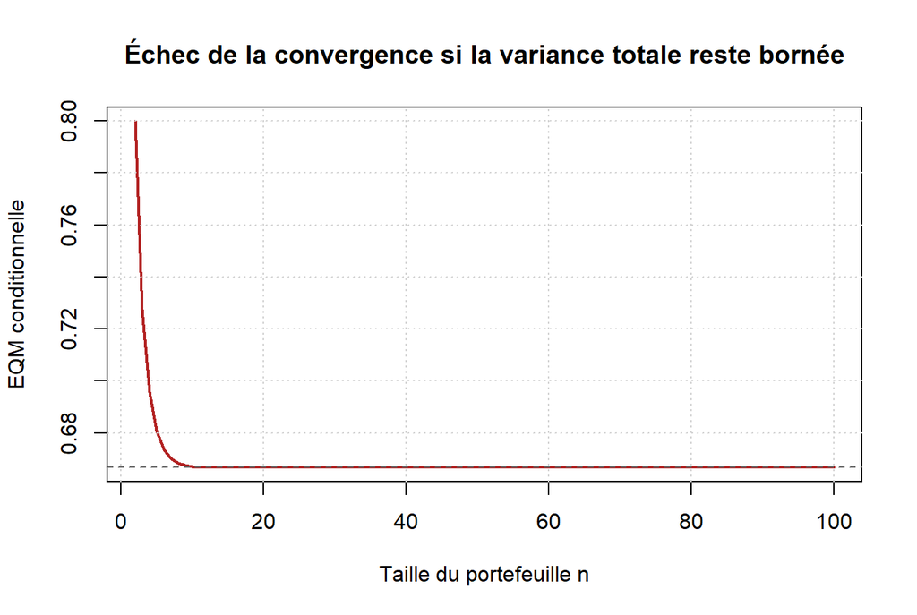

```r
n_echec <- 2:100
sigma1_carre <- 1
variance_reste <- sapply(
  n_echec,
  function(n) sum(2^(-(2:n)))
)
variance_totale_echec <- sigma1_carre + variance_reste
mse_echec <- sigma1_carre^2 / variance_totale_echec

plot(
  n_echec,
  mse_echec,
  type = "l",
  lwd = 2,
  col = "firebrick",
  xlab = "Taille du portefeuille n",
  ylab = "EQM conditionnelle",
  main = "Échec de la convergence si la variance totale reste bornée"
)
abline(
  h = sigma1_carre^2 / (sigma1_carre + 0.5),
  lty = 2,
  col = "gray40"
)
grid()
```

# 9 Lien avec la prime pure et les modèles de régression

## 9.1 Deux niveaux de conditionnement à distinguer

Le conditionnement par le total du portefeuille,

$$\mathbb E[S_i\mid T_n],$$

est un outil théorique permettant d’étudier la quantité d’information individuelle contenue dans l’expérience agrégée.

En tarification, l’information pertinente est plutôt le vecteur de caractéristiques observables du contrat,

$$\boldsymbol X_i
=
(X_{i1},\ldots,X_{ip}),$$

qui peut contenir, par exemple, l’âge, le type de véhicule, la région, la couverture ou l’exposition.

La prime pure conditionnelle est alors

$$\boxed{
\pi(\boldsymbol X_i)
=
\mathbb E[S_i\mid\boldsymbol X_i].
}$$

Si les caractéristiques sont considérées comme fixées, on peut écrire

$$\mu_i
=
\mathbb E[S_i\mid\boldsymbol X_i]
=
\pi(\boldsymbol X_i).$$

Un modèle de régression estime cette fonction inconnue à partir des données :

$$\mu_i
=
\pi(\boldsymbol X_i)
\approx
\widehat\pi(\boldsymbol X_i).$$

> Dans un portefeuille hétérogène, la cible actuarielle utile n’est généralement pas la moyenne marginale commune $\mathbb E[S]$, mais l’espérance conditionnelle propre au profil de risque : $\mathbb E[S_i\mid\boldsymbol X_i]$.

## 9.2 Décomposition fréquence-coût

Pour un montant total de sinistres, on peut écrire

$$S_i=\sum_{k=1}^{N_i}Y_{ik},$$

où $N_i$ est le nombre de sinistres et $Y_{ik}$ leur coût. Sous une hypothèse conditionnelle appropriée,

$$\mathbb E[S_i\mid\boldsymbol X_i]
=
\mathbb E[N_i\mid\boldsymbol X_i]
\times
\mathbb E[Y_{ik}\mid\boldsymbol X_i].$$

Cela motive l’estimation séparée :

- d’un modèle de fréquence, souvent Poisson ou binomial négatif ;
- d’un modèle de coût, souvent gamma ou lognormal ;
- ou d’un modèle direct du coût total, par exemple un modèle de Tweedie.

# 10 Synthèse

Les principaux enseignements sont les suivants.

1. La convergence
   $$\mathbb E[S_i\mid T_n]\to\mathbb E[S_i]$$
   exprime une **dilution de l’information individuelle** contenue dans le total d’un grand portefeuille.
2. L’indépendance seule ne suffit pas. Il faut notamment que le reste du portefeuille devienne suffisamment variable et qu’aucun contrat ne domine le total.
3. Dans les modèles normal et Poisson, la convergence peut être démontrée exactement :
   $$\operatorname{EQM}_{\mathrm{normal}}
   =\frac{\sigma_i^4}{\sum_{j=1}^n\sigma_j^2},$$
   et
   $$\operatorname{EQM}_{\mathrm{Poisson}}
   =\frac{\lambda_i^2}{\sum_{j=1}^n\lambda_j}.$$
4. La prime pure en tarification est une espérance conditionnelle fondée sur les caractéristiques du risque :
   $$\pi(\boldsymbol X_i)
   =\mathbb E[S_i\mid\boldsymbol X_i].$$
5. Le rôle du modèle de régression est d’estimer cette fonction à partir des données :
   $$\widehat\pi(\boldsymbol X_i)
   \approx
   \mathbb E[S_i\mid\boldsymbol X_i].$$

> Le total du portefeuille perd progressivement son pouvoir informatif sur un contrat fixé, tandis que les caractéristiques individuelles restent précisément l’information que le modèle de tarification cherche à exploiter.